# Intro to R

Larisa M. Soto

2022-09-13

[figure not shown]

This workshop is beginner-level introduction to programming in R. The course is designed to be taught in two sessions of 3 hours each and is focused on the application of R to the analysis of tabular data from clinical trials.

# 1 The basics

## 1.1 Installing packages

There are multiple sources and ways to do this.

**CRAN**

```r
install.packages(c("tibble","janitor","gapminder","medicaldata"),repos="https://stat.ethz.ch/CRAN/")
```

**BioConductor**

For more details about the project you can visit https://www.bioconductor.org

To install packages from BioConductor you first need to install BioConductor itself.

```r
if (!require("BiocManager", quietly = TRUE))
    install.packages("BiocManager","https://stat.ethz.ch/CRAN/")
BiocManager::install(version = "3.15")
```

Then you can install any package you want by using the `install`

```r
BiocManager::install("DESeq2")
```

**GitHub**

If you want to install the development version of a package, or you are installing something that is only available on GitHub you can use `devtools`

```r
install_github('andreacirilloac/updateR')
```

## 1.2 Syntax

Comments

```r
# This is a comment line
```

Accessing content

```r
letters[1]
```

```
## [1] "a"
```

```r
letters[2]
```

```
## [1] "b"
```

```r
head(iris$Sepal.Length)
```

```
## [1] 5.1 4.9 4.7 4.6 5.0 5.4
```

## 1.3 Aritmetic Operations

```r
# Additon
2+2
```

```
## [1] 4
```

```r
# Subtraction
3-5
```

```
## [1] -2
```

```r
# Multiplication
71*9
```

```
## [1] 639
```

```r
# Division
90/3
```

```
## [1] 30
```

```r
# Power
2^3
```

```
## [1] 8
```

## 1.4 Creating variables

```r
# The convention is to use left hand assignation
var1 <- 12
var2 <- "hello world"
var1
```

```
## [1] 12
```

```r
var2
```

```
## [1] "hello world"
```

```r
# It is also possible to use the '=' sign, but is not a good practice
var1 = 12
var2 = "hello world"
var1
```

```
## [1] 12
```

```r
var2
```

```
## [1] "hello world"
```

## 1.5 Logical operators

```r
# First create two numeric variables
var1 <- 35
var2 <- 27
```

```r
# Equal to
var1 == var2
```

```
## [1] FALSE
```

```r
# Less than or equal to
var1 <= var2
```

```
## [1] FALSE
```

```r
# They also work with other classes
var1 <- "mango"
var2 <- "mangos"
```

```r
var1 == var2
```

```
## [1] FALSE
```

Strings are compared character by character until they are not equal or there are no more characters left to compare.

```r
var1 < var2
```

```
## [1] TRUE
```

We can test if a variable is contained in another object

```r
"c" %in% letters
```

```
## [1] TRUE
```

```r
"c" %in% LETTERS
```

```
## [1] FALSE
```

## 1.6 Seeking help

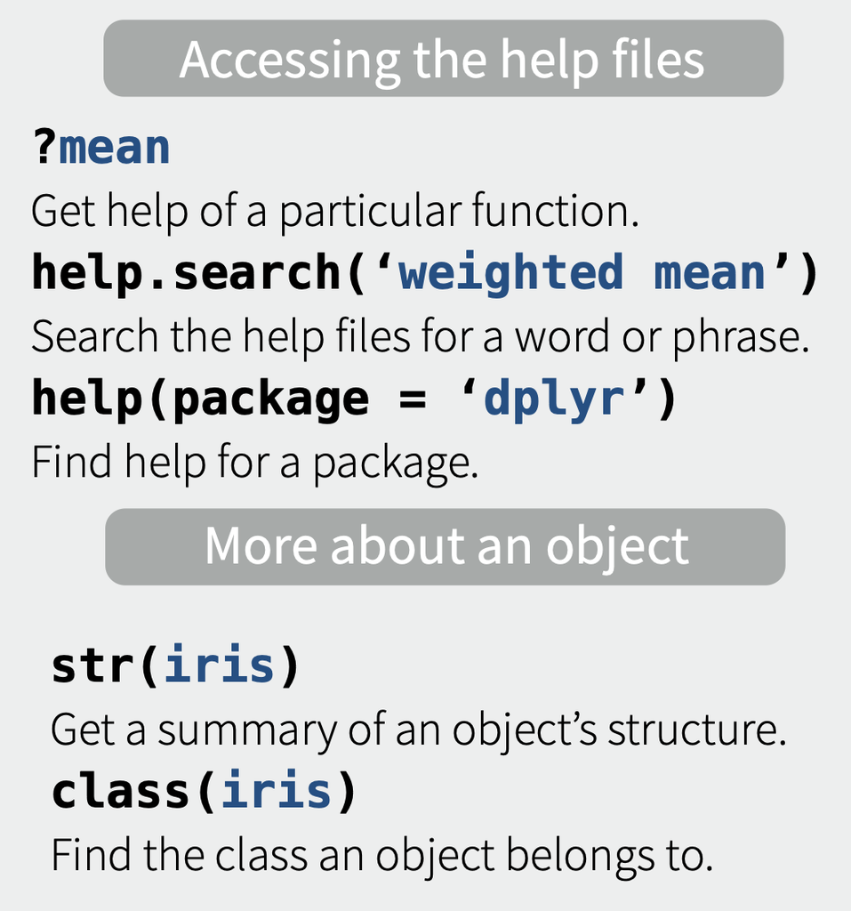

Concatenate function

```r
?c()
```

Print the description of an object

```r
str(iris)
```

```
## 'data.frame':    150 obs. of  5 variables:
##  $ Sepal.Length: num  5.1 4.9 4.7 4.6 5 5.4 4.6 5 4.4 4.9 ...
##  $ Sepal.Width : num  3.5 3 3.2 3.1 3.6 3.9 3.4 3.4 2.9 3.1 ...
##  $ Petal.Length: num  1.4 1.4 1.3 1.5 1.4 1.7 1.4 1.5 1.4 1.5 ...
##  $ Petal.Width : num  0.2 0.2 0.2 0.2 0.2 0.4 0.3 0.2 0.2 0.1 ...
##  $ Species     : Factor w/ 3 levels "setosa","versicolor",..: 1 1 1 1 1 1 1 1 1 1 ...
```

# 2 Data types

## 2.1 Vectors

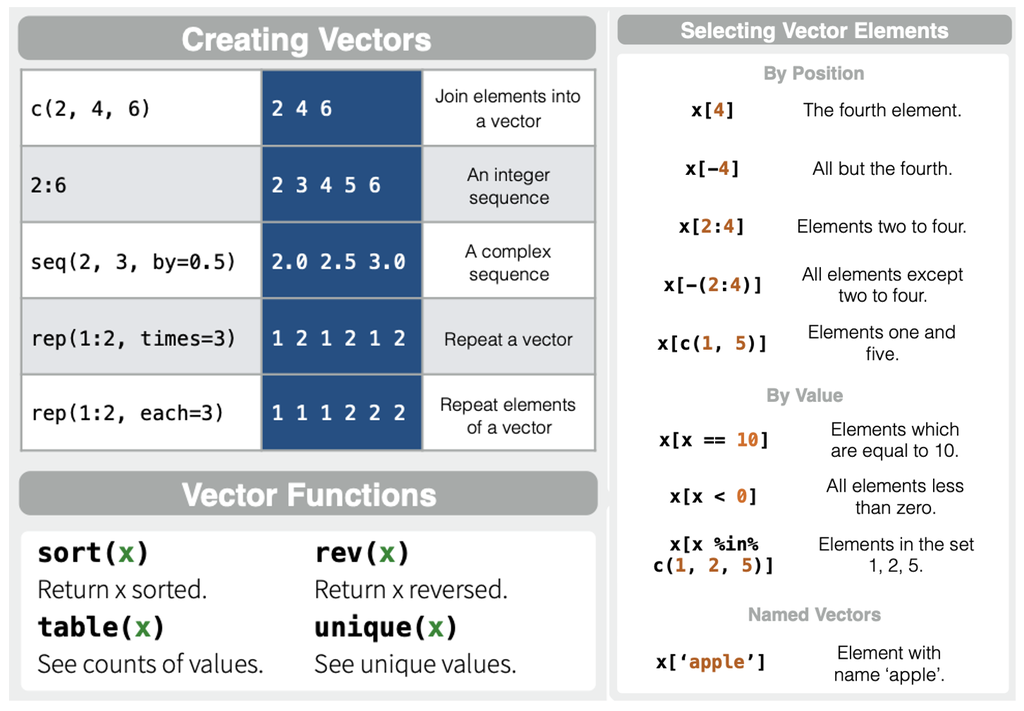

### 2.1.1 Numeric

They store numbers as `double`, and it is stored with decimals. The term double refers to the number of bytes required to store it. Each double is accurate up to 16 significant digits.

Creating a numeric vector using `c()`

```r
x <- c(0.3, 0.1)
x
```

```
## [1] 0.3 0.1
```

Using the `vector()` function

```r
x <- vector(mode = "numeric",length = 10)
x
```

```
##  [1] 0 0 0 0 0 0 0 0 0 0
```

Using the `numeric()` function

```r
x <- numeric(length = 10)
x
```

```
##  [1] 0 0 0 0 0 0 0 0 0 0
```

Creating a numeric vector with a sequence of numbers

```r
x <- seq(1,10,1)
x
```

```
##  [1]  1  2  3  4  5  6  7  8  9 10
```

```r
x <- seq(1,10,2)
x
```

```
## [1] 1 3 5 7 9
```

```r
x <- rep(2,10)
x
```

```
##  [1] 2 2 2 2 2 2 2 2 2 2
```

### 2.1.2 Integer

They store numbbers that can be written without a decimal component.

Creating an integer vector using `c()`

```r
x <- c(1L,2L,3L,4L,5L)
x
```

```
## [1] 1 2 3 4 5
```

Creating an integer vector of a sequences of numbers

```r
x <- 1:10
x
```

```
##  [1]  1  2  3  4  5  6  7  8  9 10
```

Why is this not zero ?

```r
sqrt(2)^2 - 2
```

```
## [1] 4.440892e-16
```

### 2.1.3 Logical

Creating a logical vector with `c()`

```r
x <- c(TRUE,FALSE,T,F)
x
```

```
## [1]  TRUE FALSE  TRUE FALSE
```

Creating a logical vector with `vector()`

```r
x <- vector(mode = "logical",length = 5)
x
```

```
## [1] FALSE FALSE FALSE FALSE FALSE
```

Creating a logical vector using `logical`

```r
x <- logical(length = 10)
x
```

```
##  [1] FALSE FALSE FALSE FALSE FALSE FALSE FALSE FALSE FALSE FALSE
```

### 2.1.4 Character

```r
x<-c("a","b","c")
x
```

```
## [1] "a" "b" "c"
```

```r
x<-vector(mode = "character",length=10)
x
```

```
##  [1] "" "" "" "" "" "" "" "" "" ""
```

```r
x<-character(length = 3)
x
```

```
## [1] "" "" ""
```

### 2.1.5 Vector attributes

The elements of a vector can have names

```r
x<-1:5
names(x)<-c("one","two","three","four","five")
x
```

```
##   one   two three  four  five
##     1     2     3     4     5
```

```r
x<-logical(length = 4)
names(x)<-c("F1","F2","F3","F4")
x
```

```
##    F1    F2    F3    F4
## FALSE FALSE FALSE FALSE
```

#### 2.1.5.1 Exercise

Create a vector of 5 intern first names and the name the elements of this vector with the department where they work at.

### 2.1.6 Built-in functions

To inspect the contents of a vector

```r
is.vector(x) # Check if it is a vector
```

```
## [1] TRUE
```

```r
is.na(x) # Check if it is empty
```

```
##    F1    F2    F3    F4
## FALSE FALSE FALSE FALSE
```

```r
is.null(x) # Check if it is NULL
```

```
## [1] FALSE
```

```r
is.numeric(x) # Check if it is numeric
```

```
## [1] FALSE
```

```r
is.logical(x) # Check if it is logical
```

```
## [1] TRUE
```

```r
is.character(x) # Check if it is character
```

```
## [1] FALSE
```

To know what kind of vector you are working with

```r
class(x) # Atomic class type
```

```
## [1] "logical"
```

```r
typeof(x) # Object type or data structure (matrix, list, array...)
```

```
## [1] "logical"
```

```r
str(x)
```

```
##  Named logi [1:4] FALSE FALSE FALSE FALSE
##  - attr(*, "names")= chr [1:4] "F1" "F2" "F3" "F4"
```

To know more about the data contained in the vector

```r
length(x)
```

```
## [1] 4
```

```r
table(x)
```

```
## x
## FALSE
##     4
```

```r
summary(x)
```

```
##    Mode   FALSE
## logical       4
```

Mathematical operations

```r
sum(x)
```

```
## [1] 0
```

```r
min(x)
```

```
## [1] 0
```

```r
max(x)
```

```
## [1] 0
```

```r
mean(x)
```

```
## [1] 0
```

```r
median(x)
```

```
## [1] 0
```

```r
sd(x)
```

```
## [1] 0
```

```r
log(x)
```

```
##   F1   F2   F3   F4
## -Inf -Inf -Inf -Inf
```

```r
exp(x)
```

```
## F1 F2 F3 F4
##  1  1  1  1
```

Modify strings

```r
tolower(LETTERS)
```

```
##  [1] "a" "b" "c" "d" "e" "f" "g" "h" "i" "j" "k" "l" "m" "n" "o" "p" "q" "r" "s"
## [20] "t" "u" "v" "w" "x" "y" "z"
```

```r
toupper(letters)
```

```
##  [1] "A" "B" "C" "D" "E" "F" "G" "H" "I" "J" "K" "L" "M" "N" "O" "P" "Q" "R" "S"
## [20] "T" "U" "V" "W" "X" "Y" "Z"
```

```r
paste(letters,1:length(letters),sep="_") # Note the implicit coercion
```

```
##  [1] "a_1"  "b_2"  "c_3"  "d_4"  "e_5"  "f_6"  "g_7"  "h_8"  "i_9"  "j_10"
## [11] "k_11" "l_12" "m_13" "n_14" "o_15" "p_16" "q_17" "r_18" "s_19" "t_20"
## [21] "u_21" "v_22" "w_23" "x_24" "y_25" "z_26"
```

### 2.1.7 Vector arithmetics

```r
x<-1:10
y<-11:20
```

```r
x*2
```

```
##  [1]  2  4  6  8 10 12 14 16 18 20
```

```r
x+y
```

```
##  [1] 12 14 16 18 20 22 24 26 28 30
```

```r
x*y
```

```
##  [1]  11  24  39  56  75  96 119 144 171 200
```

```r
x^y
```

```
##  [1] 1.000000e+00 4.096000e+03 1.594323e+06 2.684355e+08 3.051758e+10
##  [6] 2.821110e+12 2.326305e+14 1.801440e+16 1.350852e+18 1.000000e+20
```

#### 2.1.7.1 Exercise

Calculate the sum of the following sequence of fractions:

`x = 1/(1^2) + 1/(2^2) + 1/(3^2) + ... + 1/(n^2)`

```r
# n=100
sum(1/(1:100)^2)
```

```
## [1] 1.634984
```

```r
# n=10000
sum(1/(1:10000)^2)
```

```
## [1] 1.644834
```

### 2.1.8 Recycling

```r
x<-1:10
y<-c(1,2)
x+y
```

```
##  [1]  2  4  4  6  6  8  8 10 10 12
```

### 2.1.9 Indexing and subsetting

For this example, lets create a vector of random numbers from 1 to 100 of size 15.

```r
x<-sample(x = 1:100,size = 15,replace = F)
x
```

```
##  [1] 12 15 66 30 47 41 96 31 50  1 93 95 43 22 33
```

Using the index/position

```r
x[1] # Get the first element
```

```
## [1] 12
```

```r
x[13] # Get the thirteenth element
```

```
## [1] 43
```

Using a vector of indices

```r
x[1:12] # The first 12 numbers
```

```
##  [1] 12 15 66 30 47 41 96 31 50  1 93 95
```

```r
x[c(1,5,6,8,9,13)] # Specific positions only
```

```
## [1] 12 47 41 31 50 43
```

Using a logical vector

```r
# Only numbers that are less than or equal to 10
x<10
```

```
##  [1] FALSE FALSE FALSE FALSE FALSE FALSE FALSE FALSE FALSE  TRUE FALSE FALSE
## [13] FALSE FALSE FALSE
```

```r
x[x<=10]
```

```
## [1] 1
```

```r
# Only even numbers
x%%2 == 0
```

```
##  [1]  TRUE FALSE  TRUE  TRUE FALSE FALSE  TRUE FALSE  TRUE FALSE FALSE FALSE
## [13] FALSE  TRUE FALSE
```

```r
x[x%%2 == 0]
```

```
## [1] 12 66 30 96 50 22
```

```r
x<10
```

```
##  [1] FALSE FALSE FALSE FALSE FALSE FALSE FALSE FALSE FALSE  TRUE FALSE FALSE
## [13] FALSE FALSE FALSE
```

```r
x[x<=10] # Only numbers that are less than or equal to 10
```

```
## [1] 1
```

Skipping elements using indices

```r
x[c(-1, -5)]
```

```
##  [1] 15 66 30 41 96 31 50  1 93 95 43 22 33
```

Skipping elements using names

```r
x<-1:10
names(x)<-letters[1:10]
x[names(x) != "a"]
```

```
##  b  c  d  e  f  g  h  i  j
##  2  3  4  5  6  7  8  9 10
```

#### 2.1.9.1 Exercise

Find all the odd numbers in `x`

## 2.2 Lists

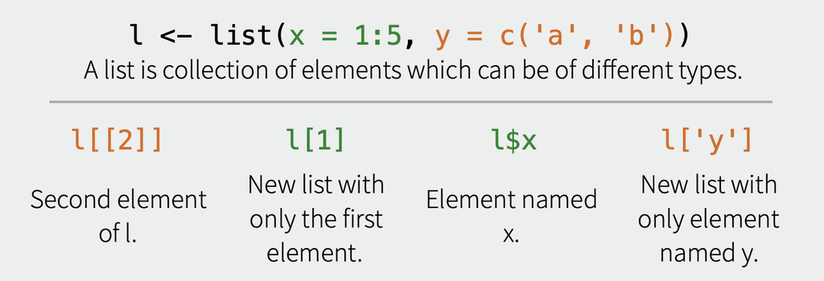

Creating lists with different data types

```r
l <- list(10, "hello", TRUE)
l
```

```
## [[1]]
## [1] 10
##
## [[2]]
## [1] "hello"
##
## [[3]]
## [1] TRUE
```

Assigning names as we create the list

```r
l<-list(title = "Numbers",
        numbers = 1:10,
        logic = TRUE )
l
```

```
## $title
## [1] "Numbers"
##
## $numbers
##  [1]  1  2  3  4  5  6  7  8  9 10
##
## $logic
## [1] TRUE
```

```r
names(l)
```

```
## [1] "title"   "numbers" "logic"
```

### 2.2.1 Indexing and subsetting

Using `[[]]` instead of `[]`

```r
l[[1]]
```

```
## [1] "Numbers"
```

Using `$` for named lists

```r
l$logic
```

```
## [1] TRUE
```

### 2.2.2 Built-in functions

```r
l<-list(sample(1:100,10),
        sample(1:100,10),
        sample(1:100,10))
names(l)<-c("r1","r2","r3")
```

Performing operations on all elements of the list using `lapply`

```r
lsums<-lapply(l,sum)
lsums
```

```
## $r1
## [1] 586
##
## $r2
## [1] 609
##
## $r3
## [1] 511
```

## 2.3 Factors

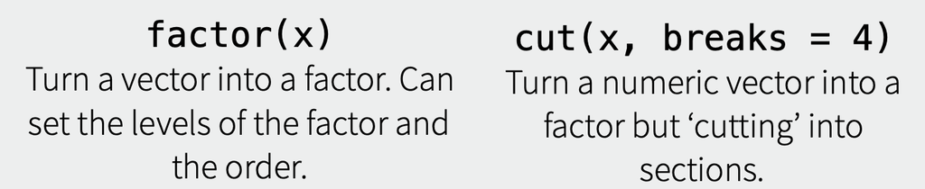

Creating factors with `factor`

```r
cols<-factor(x = c(rep("red",4),rep("blue",5),rep("green",2)),
             levels = c("red","blue","green"))
cols
```

```
##  [1] red   red   red   red   blue  blue  blue  blue  blue  green green
## Levels: red blue green
```

```r
samples <- c("case", "control", "control", "case")
samples
```

```
## [1] "case"    "control" "control" "case"
```

```r
samples_factor <- factor(samples, levels = c("control", "case"))
samples_factor
```

```
## [1] case    control control case
## Levels: control case
```

```r
str(samples_factor)
```

```
##  Factor w/ 2 levels "control","case": 2 1 1 2
```

### 2.3.1 Built-in functions

Grouping elements in a vector using `tapply`

```r
measurements<-sample(1:1000,6)
samples<-factor(c(rep("case",3),rep("control",3)), levels = c("control", "case"))
```

```r
tapply(measurements, samples, mean)
```

```
##  control     case
## 463.6667 658.6667
```

## 2.4 Matrices

Creating a matrix full of zeros with `matrix()`

```r
m<-matrix(0, ncol=6, nrow=3)
m
```

```
##      [,1] [,2] [,3] [,4] [,5] [,6]
## [1,]    0    0    0    0    0    0
## [2,]    0    0    0    0    0    0
## [3,]    0    0    0    0    0    0
```

```r
class(m)
```

```
## [1] "matrix" "array"
```

```r
typeof(m)
```

```
## [1] "double"
```

Creating a matrix from a vector of numbers

```r
m<-matrix(1:10, ncol=2, nrow=5)
m
```

```
##      [,1] [,2]
## [1,]    1    6
## [2,]    2    7
## [3,]    3    8
## [4,]    4    9
## [5,]    5   10
```

### 2.4.1 Attributes

Names of each dimension

```r
colnames(m)<-letters[1:2]
rownames(m)<-LETTERS[1:5]
m
```

```
##   a  b
## A 1  6
## B 2  7
## C 3  8
## D 4  9
## E 5 10
```

```r
str(m)
```

```
##  int [1:5, 1:2] 1 2 3 4 5 6 7 8 9 10
##  - attr(*, "dimnames")=List of 2
##   ..$ : chr [1:5] "A" "B" "C" "D" ...
##   ..$ : chr [1:2] "a" "b"
```

### 2.4.2 Built-in functions

To know the size of the matrix

```r
dim(m)
```

```
## [1] 5 2
```

```r
ncol(m)
```

```
## [1] 2
```

```r
nrow(m)
```

```
## [1] 5
```

#### 2.4.2.1 Exercise

What do you think that `length(m)` will return?

## 2.5 Data frames

Columns in data frames are vectors, and each column can be of a different data type

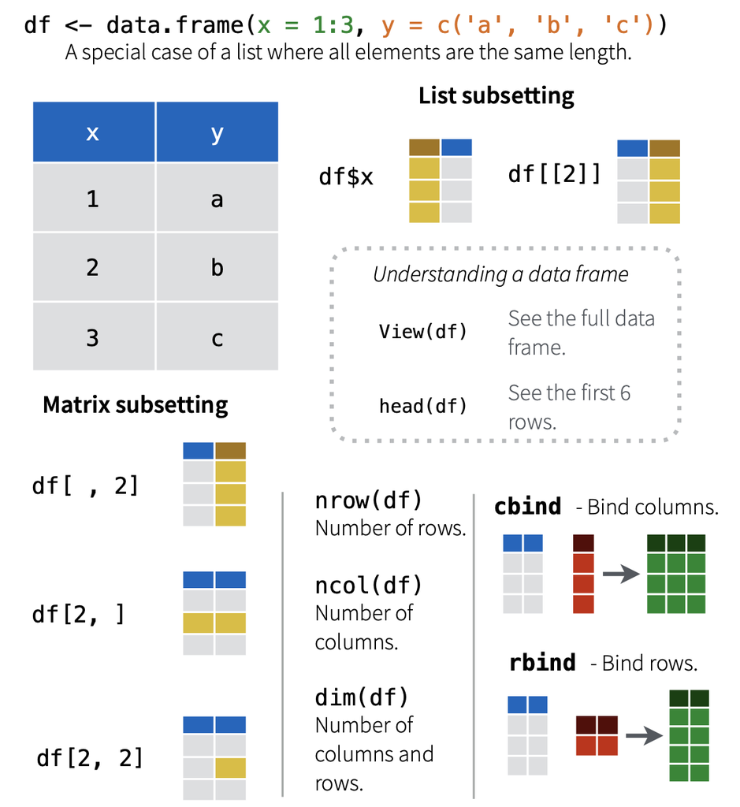

Creating a data frame using `data.frame()`

```r
df<-data.frame(numbers=1:10,
               low_letters=letters[1:10],
               logical_values=rep(c(T,F),each=5))
df
```

```
##    numbers low_letters logical_values
## 1        1           a           TRUE
## 2        2           b           TRUE
## 3        3           c           TRUE
## 4        4           d           TRUE
## 5        5           e           TRUE
## 6        6           f          FALSE
## 7        7           g          FALSE
## 8        8           h          FALSE
## 9        9           i          FALSE
## 10      10           j          FALSE
```

```r
class(df)
```

```
## [1] "data.frame"
```

```r
typeof(df)
```

```
## [1] "list"
```

```r
str(df)
```

```
## 'data.frame':    10 obs. of  3 variables:
##  $ numbers       : int  1 2 3 4 5 6 7 8 9 10
##  $ low_letters   : chr  "a" "b" "c" "d" ...
##  $ logical_values: logi  TRUE TRUE TRUE TRUE TRUE FALSE ...
```

Re-naming columns

```r
colnames(df)[2]<-"lowercase"
head(df)
```

```
##   numbers lowercase logical_values
## 1       1         a           TRUE
## 2       2         b           TRUE
## 3       3         c           TRUE
## 4       4         d           TRUE
## 5       5         e           TRUE
## 6       6         f          FALSE
```

### 2.5.1 Indexing and subsetting

```r
df$numbers
```

```
##  [1]  1  2  3  4  5  6  7  8  9 10
```

```r
df["numbers"]
```

```
##    numbers
## 1        1
## 2        2
## 3        3
## 4        4
## 5        5
## 6        6
## 7        7
## 8        8
## 9        9
## 10      10
```

```r
df[1,]
```

```
##   numbers lowercase logical_values
## 1       1         a           TRUE
```

```r
df[,1]
```

```
##  [1]  1  2  3  4  5  6  7  8  9 10
```

## 2.6 Coercion

Converting between data types with `as.` functions

```r
x<-1:10
as.list(x)
```

```
## [[1]]
## [1] 1
##
## [[2]]
## [1] 2
##
## [[3]]
## [1] 3
##
## [[4]]
## [1] 4
##
## [[5]]
## [1] 5
##
## [[6]]
## [1] 6
##
## [[7]]
## [1] 7
##
## [[8]]
## [1] 8
##
## [[9]]
## [1] 9
##
## [[10]]
## [1] 10
```

```r
l<-list(numbers=1:10,
        lowercase=letters[1:10])
l
```

```
## $numbers
##  [1]  1  2  3  4  5  6  7  8  9 10
##
## $lowercase
##  [1] "a" "b" "c" "d" "e" "f" "g" "h" "i" "j"
```

```r
typeof(l)
```

```
## [1] "list"
```

```r
df<-as.data.frame(l)
df
```

```
##    numbers lowercase
## 1        1         a
## 2        2         b
## 3        3         c
## 4        4         d
## 5        5         e
## 6        6         f
## 7        7         g
## 8        8         h
## 9        9         i
## 10      10         j
```

```r
typeof(df)
```

```
## [1] "list"
```

## 2.7 Hands on: Data types

- Make a vector with the numbers 1 through 26. Multiply the vector by 2, and give the resulting vector names A through Z (hint: there is a built in vector called LETTERS).
- Make a matrix with the numbers 1:50, with 5 columns and 10 rows. Did the matrix function fill your matrix by column, or by row, as its default behavior? Once you have figured it out, try to change the default. (hint: read the documentation for `matrix`).
- Create a list of length two containing a character vector for each of the data sections: (1) Data types and (2) Data structures. Populate each character vector with the names of the data types and data structures, respectively.
- There are several subtly different ways to call variables, observations and elements from data frames. Try them all and discuss with your team what they return. (Hint, use the function `typeof()`)
- Take the list you created in 3 and coerce it into a data frame. Then change the names of the columns to “dataTypes” and “dataStructures”.

# 3 Basic data manipulation

For this section we will use the package `gapminder` that we installed earlier.

```r
library(gapminder)
dim(gapminder)
```

```
## [1] 1704    6
```

```r
#View(gapminder)
```

```r
summary(gapminder$country)
```

```
##              Afghanistan                  Albania                  Algeria
##                       12                       12                       12
##                   Angola                Argentina                Australia
##                       12                       12                       12
##                  Austria                  Bahrain               Bangladesh
##                       12                       12                       12
##                  Belgium                    Benin                  Bolivia
##                       12                       12                       12
##   Bosnia and Herzegovina                 Botswana                   Brazil
##                       12                       12                       12
##                 Bulgaria             Burkina Faso                  Burundi
##                       12                       12                       12
##                 Cambodia                 Cameroon                   Canada
##                       12                       12                       12
## Central African Republic                     Chad                    Chile
##                       12                       12                       12
##                    China                 Colombia                  Comoros
##                       12                       12                       12
##         Congo, Dem. Rep.              Congo, Rep.               Costa Rica
##                       12                       12                       12
##            Cote d'Ivoire                  Croatia                     Cuba
##                       12                       12                       12
##           Czech Republic                  Denmark                 Djibouti
##                       12                       12                       12
##       Dominican Republic                  Ecuador                    Egypt
##                       12                       12                       12
##              El Salvador        Equatorial Guinea                  Eritrea
##                       12                       12                       12
##                 Ethiopia                  Finland                   France
##                       12                       12                       12
##                    Gabon                   Gambia                  Germany
##                       12                       12                       12
##                    Ghana                   Greece                Guatemala
##                       12                       12                       12
##                   Guinea            Guinea-Bissau                    Haiti
##                       12                       12                       12
##                 Honduras         Hong Kong, China                  Hungary
##                       12                       12                       12
##                  Iceland                    India                Indonesia
##                       12                       12                       12
```

[output cut: 13 more lines]

```
##                       12                       12                       12
##                Mauritius                   Mexico                 Mongolia
##                       12                       12                       12
##               Montenegro                  Morocco               Mozambique
##                       12                       12                       12
##                  Myanmar                  Namibia                    Nepal
##                       12                       12                       12
##              Netherlands              New Zealand                Nicaragua
##                       12                       12                       12
##                    Niger                  Nigeria                   Norway
##                       12                       12                       12
##                     Oman                 Pakistan                   Panama
##                       12                       12                       12
##                  (Other)
##                      516
```

## 3.1 Reading/writing data

### 3.1.1 Text files

Writing tables to a file using `write.table()`

```r
aust <- gapminder[gapminder$country == "Australia",]
write.table(aust,
            file="data/gapminder_australia.csv",
            sep=",")
```

```r
write.table(aust,
            file="data/gapminder_australia.csv",
            sep=",",
            quote=FALSE,
            row.names=FALSE)
```

```r
write.table(aust,
            file="data/gapminder_australia.tsv",
            sep="\t",
            quote=FALSE,
            row.names=FALSE)
```

Other functions to write to a file

```r
africa<-gapminder[gapminder$continent=="Africa",]
write.csv(gapminder[gapminder$continent=="Africa",],
          file = "data/gapminder_africa.csv",
          row.names = FALSE)
class(africa$continent)
```

```
## [1] "factor"
```

Reading data from a file

```r
africa<-read.csv("data/gapminder_africa.csv",sep = ",",header = T)
class(africa$continent)
```

```
## [1] "character"
```

```r
africa<-read.table("data/gapminder_africa.csv",sep = ",",header = T,stringsAsFactors = T)
class(africa$continent)
```

```
## [1] "factor"
```

### 3.1.2 R objects

Using `.RDS` files

```r
saveRDS(africa,file = "objects/africa.RDS")
```

```r
africa<-readRDS(file = "objects/africa.RDS")
```

Using `.RData` files

```r
americas<-gapminder[gapminder$continent=="Americas",]
save(africa,americas,file = "objects/continents.RData")
```

```r
load(file = "objects/continents.RData",verbose = T)
```

```
## Loading objects:
##   africa
##   americas
```

## 3.2 Exploring data frames

### 3.2.1 Adding columns and rows

Individually adding columns

```r
mean_children <- sample(1:10,nrow(aust),replace = TRUE)
aust$mean_children <- mean_children
head(aust)
```

```
## # A tibble: 6 × 7
##   country   continent  year lifeExp      pop gdpPercap mean_children
##   <fct>     <fct>     <int>   <dbl>    <int>     <dbl>         <int>
## 1 Australia Oceania    1952    69.1  8691212    10040.             7
## 2 Australia Oceania    1957    70.3  9712569    10950.             1
## 3 Australia Oceania    1962    70.9 10794968    12217.             2
## 4 Australia Oceania    1967    71.1 11872264    14526.             7
## 5 Australia Oceania    1972    71.9 13177000    16789.             5
## 6 Australia Oceania    1977    73.5 14074100    18334.             4
```

```r
mean_bikes <- sample(1:4,nrow(aust),replace = TRUE) # Check what happens if they don't have the same number of rows
aust[,"mean_bikes"]<-mean_bikes
head(aust)
```

```
## # A tibble: 6 × 8
##   country   continent  year lifeExp      pop gdpPercap mean_children mean_bikes
##   <fct>     <fct>     <int>   <dbl>    <int>     <dbl>         <int>      <int>
## 1 Australia Oceania    1952    69.1  8691212    10040.             7          2
## 2 Australia Oceania    1957    70.3  9712569    10950.             1          1
## 3 Australia Oceania    1962    70.9 10794968    12217.             2          3
## 4 Australia Oceania    1967    71.1 11872264    14526.             7          3
## 5 Australia Oceania    1972    71.9 13177000    16789.             5          4
## 6 Australia Oceania    1977    73.5 14074100    18334.             4          1
```

Combining data frames

```r
aust <- gapminder[gapminder$country=="Australia",]
df <- data.frame(mean_children=sample(1:10,nrow(aust),replace = TRUE),
               mean_bikes=sample(1:4,nrow(aust),replace = TRUE))
head(df)
```

```
##   mean_children mean_bikes
## 1             2          1
## 2             9          1
## 3             5          3
## 4             8          3
## 5             4          4
## 6             5          1
```

```r
aust <- cbind(aust,df)
head(aust)
```

```
##     country continent year lifeExp      pop gdpPercap mean_children mean_bikes
## 1 Australia   Oceania 1952   69.12  8691212  10039.60             2          1
## 2 Australia   Oceania 1957   70.33  9712569  10949.65             9          1
## 3 Australia   Oceania 1962   70.93 10794968  12217.23             5          3
## 4 Australia   Oceania 1967   71.10 11872264  14526.12             8          3
## 5 Australia   Oceania 1972   71.93 13177000  16788.63             4          4
## 6 Australia   Oceania 1977   73.49 14074100  18334.20             5          1
```

Individually adding rows

```r
new_row<-list("country" = "Australia",
               "continent" = "Oceania",
               "year" = 2022,
               "lifeExp" = mean(aust$lifeExp),
               "pop" = mean(aust$pop),
               "gdpPercap" = mean(aust$gdpPercap),
               "mean_children" = floor(mean(aust$mean_children)),
               "mean_bikes" = floor(mean(aust$mean_children))) # Why did I create it as list?
new_row
```

```
## $country
## [1] "Australia"
##
## $continent
## [1] "Oceania"
##
## $year
## [1] 2022
##
## $lifeExp
## [1] 74.66292
##
## $pop
## [1] 14649312
##
## $gdpPercap
## [1] 19980.6
##
## $mean_children
## [1] 4
##
## $mean_bikes
## [1] 4
```

```r
aust<-rbind(aust,new_row)
tail(aust)
```

```
##      country continent year  lifeExp      pop gdpPercap mean_children
## 8  Australia   Oceania 1987 76.32000 16257249  21888.89             2
## 9  Australia   Oceania 1992 77.56000 17481977  23424.77             4
## 10 Australia   Oceania 1997 78.83000 18565243  26997.94             3
## 11 Australia   Oceania 2002 80.37000 19546792  30687.75             8
## 12 Australia   Oceania 2007 81.23500 20434176  34435.37             2
## 13 Australia   Oceania 2022 74.66292 14649312  19980.60             4
##    mean_bikes
## 8           4
## 9           1
## 10          1
## 11          2
## 12          1
## 13          4
```

Combining data frames by rows

```r
dim(aust)
```

```
## [1] 13  8
```

```r
aust_double<-rbind(aust,aust)
dim(aust_double)
```

```
## [1] 26  8
```

### 3.2.2 Removing columns and rows

```r
aust<-aust[,-ncol(aust)]# remove the last column
head(aust)
```

```
##     country continent year lifeExp      pop gdpPercap mean_children
## 1 Australia   Oceania 1952   69.12  8691212  10039.60             2
## 2 Australia   Oceania 1957   70.33  9712569  10949.65             9
## 3 Australia   Oceania 1962   70.93 10794968  12217.23             5
## 4 Australia   Oceania 1967   71.10 11872264  14526.12             8
## 5 Australia   Oceania 1972   71.93 13177000  16788.63             4
## 6 Australia   Oceania 1977   73.49 14074100  18334.20             5
```

```r
aust<-aust[,colnames(aust)!="mean_children"]# remove column by name
head(aust)
```

```
##     country continent year lifeExp      pop gdpPercap
## 1 Australia   Oceania 1952   69.12  8691212  10039.60
## 2 Australia   Oceania 1957   70.33  9712569  10949.65
## 3 Australia   Oceania 1962   70.93 10794968  12217.23
## 4 Australia   Oceania 1967   71.10 11872264  14526.12
## 5 Australia   Oceania 1972   71.93 13177000  16788.63
## 6 Australia   Oceania 1977   73.49 14074100  18334.20
```

```r
dim(aust[-1,]) # Remove the first row
```

```
## [1] 12  6
```

```r
dim(aust[-1*1:10,]) # Remove the first 10 rows
```

```
## [1] 3 6
```

### 3.2.3 Applying filters

```r
aust[aust$lifeExp>=70,]
```

```
##      country continent year  lifeExp      pop gdpPercap
## 2  Australia   Oceania 1957 70.33000  9712569  10949.65
## 3  Australia   Oceania 1962 70.93000 10794968  12217.23
## 4  Australia   Oceania 1967 71.10000 11872264  14526.12
## 5  Australia   Oceania 1972 71.93000 13177000  16788.63
## 6  Australia   Oceania 1977 73.49000 14074100  18334.20
## 7  Australia   Oceania 1982 74.74000 15184200  19477.01
## 8  Australia   Oceania 1987 76.32000 16257249  21888.89
## 9  Australia   Oceania 1992 77.56000 17481977  23424.77
## 10 Australia   Oceania 1997 78.83000 18565243  26997.94
## 11 Australia   Oceania 2002 80.37000 19546792  30687.75
## 12 Australia   Oceania 2007 81.23500 20434176  34435.37
## 13 Australia   Oceania 2022 74.66292 14649312  19980.60
```

```r
aust[aust$gdpPercap>=mean(aust$gdpPercap),]
```

```
##      country continent year  lifeExp      pop gdpPercap
## 8  Australia   Oceania 1987 76.32000 16257249  21888.89
## 9  Australia   Oceania 1992 77.56000 17481977  23424.77
## 10 Australia   Oceania 1997 78.83000 18565243  26997.94
## 11 Australia   Oceania 2002 80.37000 19546792  30687.75
## 12 Australia   Oceania 2007 81.23500 20434176  34435.37
## 13 Australia   Oceania 2022 74.66292 14649312  19980.60
```

How to get unique entries/remove duplicates

```r
unique(aust_double)
```

```
##      country continent year  lifeExp      pop gdpPercap mean_children
## 1  Australia   Oceania 1952 69.12000  8691212  10039.60             2
## 2  Australia   Oceania 1957 70.33000  9712569  10949.65             9
## 3  Australia   Oceania 1962 70.93000 10794968  12217.23             5
## 4  Australia   Oceania 1967 71.10000 11872264  14526.12             8
## 5  Australia   Oceania 1972 71.93000 13177000  16788.63             4
## 6  Australia   Oceania 1977 73.49000 14074100  18334.20             5
## 7  Australia   Oceania 1982 74.74000 15184200  19477.01             7
## 8  Australia   Oceania 1987 76.32000 16257249  21888.89             2
## 9  Australia   Oceania 1992 77.56000 17481977  23424.77             4
## 10 Australia   Oceania 1997 78.83000 18565243  26997.94             3
## 11 Australia   Oceania 2002 80.37000 19546792  30687.75             8
## 12 Australia   Oceania 2007 81.23500 20434176  34435.37             2
## 13 Australia   Oceania 2022 74.66292 14649312  19980.60             4
##    mean_bikes
## 1           1
## 2           1
## 3           3
## 4           3
## 5           4
## 6           1
## 7           2
## 8           4
## 9           1
## 10          1
## 11          2
## 12          1
## 13          4
```

To remove empty rows

```r
# First lets add an empty row
na.list<-rep(NA,ncol(aust))
aust<-rbind(aust,na.list)
tail(aust)
```

```
##      country continent year  lifeExp      pop gdpPercap
## 9  Australia   Oceania 1992 77.56000 17481977  23424.77
## 10 Australia   Oceania 1997 78.83000 18565243  26997.94
## 11 Australia   Oceania 2002 80.37000 19546792  30687.75
## 12 Australia   Oceania 2007 81.23500 20434176  34435.37
## 13 Australia   Oceania 2022 74.66292 14649312  19980.60
## 14      <NA>      <NA>   NA       NA       NA        NA
```

```r
aust<-aust[!is.na(aust$country),]
tail(aust)
```

```
##      country continent year  lifeExp      pop gdpPercap
## 8  Australia   Oceania 1987 76.32000 16257249  21888.89
## 9  Australia   Oceania 1992 77.56000 17481977  23424.77
## 10 Australia   Oceania 1997 78.83000 18565243  26997.94
## 11 Australia   Oceania 2002 80.37000 19546792  30687.75
## 12 Australia   Oceania 2007 81.23500 20434176  34435.37
## 13 Australia   Oceania 2022 74.66292 14649312  19980.60
```

### 3.2.4 Editing specific elements

```r
aust[1,"lifeExp"]<-aust[1,"lifeExp"]+1
```

## 3.3 Hands-on: basic data manipulation

1. Write a data processing snippet to include only the data points collected after 1995 in Asian countries as a CSV file.
2. Separate the `gapminder` data frame into 5 individual data frames, one for each continent. Store those 5 data frames as an `RData` file called `continents.RData` in the `objects` folder.
3. Finish exploring the `gapminder` data frame and:
- Find the number of rows and the number of columns
- Print the data type of each column
- Explain the meaning of everything that `str(gapminder)` prints
4. In which years has the GDP of Canada been larger than the average of all data points?
5. Find the mean life expectancy of Switzerland before and after 2000
6. You discovered that all the entries from 2007 are actually from 2008. Create a copy of the full `gapminder` data frame in an object called `gp`. Then change the year column to correct the entries from 2007.
7. **Bonus -** Find the mean life expectancy and mean gdp per continent using the function `tapply`

# 4 Control structures and functions

## 4.1 `if` statement

As a general rule, the result of whatever is contained inside the `if()` has to return a single logical element (`TRUE` or `FALSE`), but you can combine multiple conditionals.

A basic condition:

```r
x <- 5
if (x > 10) {
  print("x is greater than 10")
}
x
```

```
## [1] 5
```

A basic condition with an alternative:

```r
x <- 8
if (x >= 10) {
  print("x is greater than or equal to 10")
} else {
  print("x is less than 10")
}
```

```
## [1] "x is less than 10"
```

Multiple alternatives:

```r
x <- 8

if (x >= 10) {
  print("x is greater than or equal to 10")
} else if (x > 5) {
  print("x is greater than 5 and less than 10")
} else {
  print("x is less than 5")
}
```

```
## [1] "x is greater than 5 and less than 10"
```

### 4.1.1 Useful functions

Built-in `ifelse()` function:

`ifelse(condition is true, execute instruction, execute alternative instruction)`

```r
y <- -3
ifelse(y < 0, "y is a negative number", "y is either positive or zero")
```

```
## [1] "y is a negative number"
```

The function `any()` will return `TRUE` if at least one element is `TRUE` and the function `all()` will return `TRUE` only when all the elements are `TRUE`

```r
any(gapminder$country=="Mexico")
```

```
## [1] TRUE
```

```r
all(gapminder$continent=="Europe")
```

```
## [1] FALSE
```

### 4.1.2 Exercise

Write an`if()` statement to print a message describing if there are any records from 2002 in the `gapminder` dataset. Then do the same for 2012.

```r
year<-2002
```

```r
nrows_year<-nrow(gapminder[(gapminder$year == year),])
if(nrow(gapminder[(gapminder$year == year),]) >= 1){
   print(paste("Found record(s) for the year",year))
}
```

```
## [1] "Found record(s) for the year 2002"
```

```r
if(sum(gapminder$year == year) >= 1){
   print(paste("Found record(s) for the year",year))
}
```

```
## [1] "Found record(s) for the year 2002"
```

```r
if(any(gapminder$year == year)){
   print(paste("Found record(s) for the year",year))
}
```

```
## [1] "Found record(s) for the year 2002"
```

## 4.2 `for` loop

This structure helps us repeat actions multiple times:

```r
for (i in 1:10) {
  print(i)
}
```

```
## [1] 1
## [1] 2
## [1] 3
## [1] 4
## [1] 5
## [1] 6
## [1] 7
## [1] 8
## [1] 9
## [1] 10
```

We can embedd multiple loops:

```r
for (i in 1:3) {
  for (j in c('a', 'b', 'c')) {
    print(paste(i,j))
  }
}
```

```
## [1] "1 a"
## [1] "1 b"
## [1] "1 c"
## [1] "2 a"
## [1] "2 b"
## [1] "2 c"
## [1] "3 a"
## [1] "3 b"
## [1] "3 c"
```

Create objects as the loop progresses:

```r
seqs<-c()
for (i in 1:5) {
  for (j in c('a', 'b', 'c', 'd', 'e')) {
    tmp<-paste(i,j)
    seqs<-c(seqs,tmp)
  }
}
seqs
```

```
##  [1] "1 a" "1 b" "1 c" "1 d" "1 e" "2 a" "2 b" "2 c" "2 d" "2 e" "3 a" "3 b"
## [13] "3 c" "3 d" "3 e" "4 a" "4 b" "4 c" "4 d" "4 e" "5 a" "5 b" "5 c" "5 d"
## [25] "5 e"
```

If you know the size of your output, it is better to specify it at the beginning:

```r
seqs_mat<-matrix(nrow=5,ncol=5)
let_vec<-c('a', 'b', 'c','d','e')
for (i in 1:5) {
  for (j in 1:5) {
    seqs_mat[i,j]<-paste(i,let_vec[j])
  }
}
as.vector(seqs_mat)
```

```
##  [1] "1 a" "2 a" "3 a" "4 a" "5 a" "1 b" "2 b" "3 b" "4 b" "5 b" "1 c" "2 c"
## [13] "3 c" "4 c" "5 c" "1 d" "2 d" "3 d" "4 d" "5 d" "1 e" "2 e" "3 e" "4 e"
## [25] "5 e"
```

### 4.2.1 Exercise

Make a character vector with the first 10 countries in `gapminder$counntry`in alphabetical order. Iterate over this vector to subset the `gapminder` dataset to include only the data from the corresponding country and write it into a `tsv` file. Name the file with the name of the corresponding country in lowercase inside the `data` folder.

```r
countries<-unique(gapminder$country)
top10<-countries[order(countries)][1:10]
top10<-as.character(top10)
for(tc in top10){
  df<-gapminder[gapminder$country==tc,]
  filename<-paste("data/gapminder_",tolower(tc),".tsv",sep="")
  write.table(df,file = filename,quote=FALSE,sep="\t",row.names = FALSE)
}
```

## 4.3 Functions

The general structure of a function is the following:

```r
my_function <- function(parameters) {
  # perform action
  # return value
}
```

Lets write a function to convert Farenheit to Kelvin

```r
fahr_to_kelvin <- function(temp_in_fahr) {

  # Description: converts tempearture in farenheit to kelvin
  # Input: numeric
  # Output: numeric

  kelvin <- ((temp_in_fahr - 32) * (5 / 9)) + 273.15
  return(kelvin)
}
```

```r
fahr_to_kelvin(temp_in_fahr=32) # Freezing point of water
```

```
## [1] 273.15
```

```r
fahr_to_kelvin(temp_in_fahr=212) # Boiling point of water
```

```
## [1] 373.15
```

Letw write a function to calculate the Gross Domestic Product of a country in the `gapmider` dataset

```r
calculateGDP <- function(df) {

  # Description: Takes a dataset and multiplies the population column
  #              with the GDP per capita column.
  # Input: data.frame
  # Output: numeric

  gdp <- df$pop * df$gdpPercap
  return(gdp)
}
```

```r
calculateGDP(gapminder[1:10,])
```

```
##  [1]  6567086330  7585448670  8758855797  9648014150  9678553274 11697659231
##  [7] 12598563401 11820990309 10595901589 14121995875
```

Adding more elements to the output of our function:

```r
calculateGDP <- function(df, year=NULL, country=NULL) {

  # Description: Takes a dfaset and multiplies the population column
  #              with the GDP per capita column for the country(ies) and year(s)
  #              indicated (optionl) and returns the input data frame with an
  #              additional column fro the gdp
  # Input:
  #    - df = data.frame
  #    - year = numeric (optional)
  #    - country = character (optional)
  # Output: numeric

  if(!is.null(year)) {
    df <- df[df$year %in% year, ]
  }
  if (!is.null(country)) {
    df <- df[df$country %in% country,]
  }
  gdp <- df$pop * df$gdpPercap

  new <- cbind(df, gdp=gdp)
  return(new)
}
```

```r
calculateGDP(gapminder, country = top10,year = "2002")
```

```
##        country continent year lifeExp       pop  gdpPercap          gdp
## 1  Afghanistan      Asia 2002  42.129  25268405   726.7341  18363410424
## 2      Albania    Europe 2002  75.651   3508512  4604.2117  16153932130
## 3      Algeria    Africa 2002  70.994  31287142  5288.0404 165447670333
## 4       Angola    Africa 2002  41.003  10866106  2773.2873  30134833901
## 5    Argentina  Americas 2002  74.340  38331121  8797.6407 337223430800
## 6    Australia   Oceania 2002  80.370  19546792 30687.7547 599847158654
## 7      Austria    Europe 2002  78.980   8148312 32417.6077 264148781752
## 8      Bahrain      Asia 2002  74.795    656397 23403.5593  15362026094
## 9   Bangladesh      Asia 2002  62.013 135656790  1136.3904 154159077921
## 10     Belgium    Europe 2002  78.320  10311970 30485.8838 314369518653
```

```r
head(calculateGDP(gapminder, year = "2007"))
```

```
##       country continent year lifeExp      pop  gdpPercap          gdp
## 1 Afghanistan      Asia 2007  43.828 31889923   974.5803  31079291949
## 2     Albania    Europe 2007  76.423  3600523  5937.0295  21376411360
## 3     Algeria    Africa 2007  72.301 33333216  6223.3675 207444851958
## 4      Angola    Africa 2007  42.731 12420476  4797.2313  59583895818
## 5   Argentina  Americas 2007  75.320 40301927 12779.3796 515033625357
## 6   Australia   Oceania 2007  81.235 20434176 34435.3674 703658358894
```

```r
head(calculateGDP(gapminder, country = "Argentina"))
```

```
##     country continent year lifeExp      pop gdpPercap          gdp
## 1 Argentina  Americas 1952  62.485 17876956  5911.315 105676319105
## 2 Argentina  Americas 1957  64.399 19610538  6856.856 134466639306
## 3 Argentina  Americas 1962  65.142 21283783  7133.166 151820757737
## 4 Argentina  Americas 1967  65.634 22934225  8052.953 184688236498
## 5 Argentina  Americas 1972  67.065 24779799  9443.039 233996596624
## 6 Argentina  Americas 1977  68.481 26983828 10079.027 271970723960
```

We can also combine multiple functions

```r
raw_calculate_gdp <- function(pop,gdpPercap){
  gdp <- pop * gdpPercap
  return(gdp)
}

calculateGDP <- function(df, year=NULL, country=NULL) {

  if(!is.null(year)) {
    df <- df[df$year %in% year, ]
  }
  if (!is.null(country)) {
    df <- df[df$country %in% country,]
  }
  gdp <- raw_calculate_gdp(df$pop,df$gdpPercap)

  new <- cbind(df, gdp=gdp)
  return(new)
}
```

```r
head(calculateGDP(gapminder, country = "Argentina"))
```

```
##     country continent year lifeExp      pop gdpPercap          gdp
## 1 Argentina  Americas 1952  62.485 17876956  5911.315 105676319105
## 2 Argentina  Americas 1957  64.399 19610538  6856.856 134466639306
## 3 Argentina  Americas 1962  65.142 21283783  7133.166 151820757737
## 4 Argentina  Americas 1967  65.634 22934225  8052.953 184688236498
## 5 Argentina  Americas 1972  67.065 24779799  9443.039 233996596624
## 6 Argentina  Americas 1977  68.481 26983828 10079.027 271970723960
```

If you want to write the functions into a separate file you can load them back into R with the following code

```r
source("functions/functions-day1.R")
```

# 5 Advanced data manipulation

There are several packages that allow for more sophisticated processing operations to be done faster. We will take a look at some functions from three of them.

## 5.1 Splitting and merging data frames

The package `plyr` has multiple functions to solve the “split-apply-combine” problem. They all share the same structure: - The first letter of the function name indicates the input type, the second letter indicates the output type. (l = list, d = data.frame, …)  
- `.data` receives the object that will be manipulated  
- `.variables` receives the name of the grouping column(s) - `.fun` receives the function that will be applied on each piece

```r
gdpminder<-calculateGDP(gapminder)
head(gdpminder)
```

```
##       country continent year lifeExp      pop gdpPercap         gdp
## 1 Afghanistan      Asia 1952  28.801  8425333  779.4453  6567086330
## 2 Afghanistan      Asia 1957  30.332  9240934  820.8530  7585448670
## 3 Afghanistan      Asia 1962  31.997 10267083  853.1007  8758855797
## 4 Afghanistan      Asia 1967  34.020 11537966  836.1971  9648014150
## 5 Afghanistan      Asia 1972  36.088 13079460  739.9811  9678553274
## 6 Afghanistan      Asia 1977  38.438 14880372  786.1134 11697659231
```

```r
plyr::ddply(.data = gdpminder,
            .variables = "continent",
            .fun = function(df){mean(df$gdp)})
```

```
##   continent           V1
## 1    Africa  20904782844
## 2  Americas 379262350210
## 3      Asia 227233738153
## 4    Europe 269442085301
## 5   Oceania 188187105354
```

We can do the same but discarding all records entered after the year 2000.

```r
plyr::ddply(.data = gdpminder[gdpminder$year<2000,],
            .variables = "continent",
            .fun = function(df){mean(df$gdp)})
```

```
##   continent           V1
## 1    Africa  16977531186
## 2  Americas 311317615303
## 3      Asia 164124888657
## 4    Europe 230367289746
## 5   Oceania 150935133957
```

## 5.2 Manipulation with `dplyr` and `tidyr`

We often need to select certain observations (rows) or variables (columns), or group the data by certain variable(s) to calculate some summary statistics. Although these operations can be done using base R functions, they require the creation of multiple intermediate objects and a lot of code repetition. There are two packages that provide functions to streamline common operations on tabular data and make the code look nicer and cleaner.

These packages are part of a broader family called `tidyverse`, for more information you can visit https://www.tidyverse.org/.

We will cover 5 of the most commonly used functions and combine them using pipes (`%>%`): 1. `select()` - used to extract data 2. `filter()` - to filter entries using logical vectors 3. `group_by()` - to solve the split-apply-combine problem 4. `summarize()` - to obtain summary statistics 5. `mutate()` - to create new columns

```r
library(dplyr)
library(tidyr)
```

### 5.2.1 Introducing pipes

```r
gapminder %>%
  head()
```

```
## # A tibble: 6 × 6
##   country     continent  year lifeExp      pop gdpPercap
##   <fct>       <fct>     <int>   <dbl>    <int>     <dbl>
## 1 Afghanistan Asia       1952    28.8  8425333      779.
## 2 Afghanistan Asia       1957    30.3  9240934      821.
## 3 Afghanistan Asia       1962    32.0 10267083      853.
## 4 Afghanistan Asia       1967    34.0 11537966      836.
## 5 Afghanistan Asia       1972    36.1 13079460      740.
## 6 Afghanistan Asia       1977    38.4 14880372      786.
```

```r
gapminder %>%
  tail()
```

```
## # A tibble: 6 × 6
##   country  continent  year lifeExp      pop gdpPercap
##   <fct>    <fct>     <int>   <dbl>    <int>     <dbl>
## 1 Zimbabwe Africa     1982    60.4  7636524      789.
## 2 Zimbabwe Africa     1987    62.4  9216418      706.
## 3 Zimbabwe Africa     1992    60.4 10704340      693.
## 4 Zimbabwe Africa     1997    46.8 11404948      792.
## 5 Zimbabwe Africa     2002    40.0 11926563      672.
## 6 Zimbabwe Africa     2007    43.5 12311143      470.
```

### 5.2.2 Using `select()`

To subset a data frame

```r
dplyr::select(.data = gapminder,
       year, country, gdpPercap) %>%
  head()
```

```
## # A tibble: 6 × 3
##    year country     gdpPercap
##   <int> <fct>           <dbl>
## 1  1952 Afghanistan      779.
## 2  1957 Afghanistan      821.
## 3  1962 Afghanistan      853.
## 4  1967 Afghanistan      836.
## 5  1972 Afghanistan      740.
## 6  1977 Afghanistan      786.
```

To remove columns

```r
dplyr::select(.data = gapminder,
       -continent) %>%
      head()
```

```
## # A tibble: 6 × 5
##   country      year lifeExp      pop gdpPercap
##   <fct>       <int>   <dbl>    <int>     <dbl>
## 1 Afghanistan  1952    28.8  8425333      779.
## 2 Afghanistan  1957    30.3  9240934      821.
## 3 Afghanistan  1962    32.0 10267083      853.
## 4 Afghanistan  1967    34.0 11537966      836.
## 5 Afghanistan  1972    36.1 13079460      740.
## 6 Afghanistan  1977    38.4 14880372      786.
```

```r
gapminder %>%
  dplyr::select(year, country, gdpPercap) %>%
  head()
```

```
## # A tibble: 6 × 3
##    year country     gdpPercap
##   <int> <fct>           <dbl>
## 1  1952 Afghanistan      779.
## 2  1957 Afghanistan      821.
## 3  1962 Afghanistan      853.
## 4  1967 Afghanistan      836.
## 5  1972 Afghanistan      740.
## 6  1977 Afghanistan      786.
```

Renaming columns using `dplyr`

```r
tidy_gdp <- gapminder %>%
            dplyr::select(year, country, gdpPercap) %>%
            rename(gdp_per_capita = gdpPercap)

head(tidy_gdp)
```

```
## # A tibble: 6 × 3
##    year country     gdp_per_capita
##   <int> <fct>                <dbl>
## 1  1952 Afghanistan           779.
## 2  1957 Afghanistan           821.
## 3  1962 Afghanistan           853.
## 4  1967 Afghanistan           836.
## 5  1972 Afghanistan           740.
## 6  1977 Afghanistan           786.
```

### 5.2.3 Using `filter()`

Include only European countries and select the columns year, country and gdpPercap

```r
gapminder %>%
    filter(continent == "Europe") %>%
    select(year, country, gdpPercap) %>%
    head()
```

```
## # A tibble: 6 × 3
##    year country gdpPercap
##   <int> <fct>       <dbl>
## 1  1952 Albania     1601.
## 2  1957 Albania     1942.
## 3  1962 Albania     2313.
## 4  1967 Albania     2760.
## 5  1972 Albania     3313.
## 6  1977 Albania     3533.
```

Using multiple filters at once

```r
gapminder %>%
  filter(continent == "Europe", year == 2007) %>%
  select(country, lifeExp)
```

```
## # A tibble: 30 × 2
##    country                lifeExp
##    <fct>                    <dbl>
##  1 Albania                   76.4
##  2 Austria                   79.8
##  3 Belgium                   79.4
##  4 Bosnia and Herzegovina    74.9
##  5 Bulgaria                  73.0
##  6 Croatia                   75.7
##  7 Czech Republic            76.5
##  8 Denmark                   78.3
##  9 Finland                   79.3
## 10 France                    80.7
## # … with 20 more rows
```

Extract unique entries

```r
gapminder %>%
  select(country, continent) %>%
  distinct()
```

```
## # A tibble: 142 × 2
##    country     continent
##    <fct>       <fct>
##  1 Afghanistan Asia
##  2 Albania     Europe
##  3 Algeria     Africa
##  4 Angola      Africa
##  5 Argentina   Americas
##  6 Australia   Oceania
##  7 Austria     Europe
##  8 Bahrain     Asia
##  9 Bangladesh  Asia
## 10 Belgium     Europe
## # … with 132 more rows
```

Order according to a column

```r
gapminder %>%
  select(country, continent,year,pop) %>%
  arrange(desc(pop)) %>%
  head()
```

```
## # A tibble: 6 × 4
##   country continent  year        pop
##   <fct>   <fct>     <int>      <int>
## 1 China   Asia       2007 1318683096
## 2 China   Asia       2002 1280400000
## 3 China   Asia       1997 1230075000
## 4 China   Asia       1992 1164970000
## 5 India   Asia       2007 1110396331
## 6 China   Asia       1987 1084035000
```

### 5.2.4 Using `group_by()`

It internally groups observations based on the specified variable(s)

```r
str(gapminder)
```

```
## tibble [1,704 × 6] (S3: tbl_df/tbl/data.frame)
##  $ country  : Factor w/ 142 levels "Afghanistan",..: 1 1 1 1 1 1 1 1 1 1 ...
##  $ continent: Factor w/ 5 levels "Africa","Americas",..: 3 3 3 3 3 3 3 3 3 3 ...
##  $ year     : int [1:1704] 1952 1957 1962 1967 1972 1977 1982 1987 1992 1997 ...
##  $ lifeExp  : num [1:1704] 28.8 30.3 32 34 36.1 ...
##  $ pop      : int [1:1704] 8425333 9240934 10267083 11537966 13079460 14880372 12881816 13867957 16317921 22227415 ...
##  $ gdpPercap: num [1:1704] 779 821 853 836 740 ...
```

```r
str(gapminder %>% group_by(continent))
```

```
## grouped_df [1,704 × 6] (S3: grouped_df/tbl_df/tbl/data.frame)
##  $ country  : Factor w/ 142 levels "Afghanistan",..: 1 1 1 1 1 1 1 1 1 1 ...
##  $ continent: Factor w/ 5 levels "Africa","Americas",..: 3 3 3 3 3 3 3 3 3 3 ...
##  $ year     : int [1:1704] 1952 1957 1962 1967 1972 1977 1982 1987 1992 1997 ...
##  $ lifeExp  : num [1:1704] 28.8 30.3 32 34 36.1 ...
##  $ pop      : int [1:1704] 8425333 9240934 10267083 11537966 13079460 14880372 12881816 13867957 16317921 22227415 ...
##  $ gdpPercap: num [1:1704] 779 821 853 836 740 ...
##  - attr(*, "groups")= tibble [5 × 2] (S3: tbl_df/tbl/data.frame)
##   ..$ continent: Factor w/ 5 levels "Africa","Americas",..: 1 2 3 4 5
##   ..$ .rows    : list<int> [1:5]
##   .. ..$ : int [1:624] 25 26 27 28 29 30 31 32 33 34 ...
##   .. ..$ : int [1:300] 49 50 51 52 53 54 55 56 57 58 ...
##   .. ..$ : int [1:396] 1 2 3 4 5 6 7 8 9 10 ...
##   .. ..$ : int [1:360] 13 14 15 16 17 18 19 20 21 22 ...
##   .. ..$ : int [1:24] 61 62 63 64 65 66 67 68 69 70 ...
##   .. ..@ ptype: int(0)
##   ..- attr(*, ".drop")= logi TRUE
```

### 5.2.5 Using `summarize()`

```r
gdp_c <- gapminder %>%
          group_by(continent) %>%
          summarize(mean_gdpPercap = mean(gdpPercap))
gdp_c
```

```
## # A tibble: 5 × 2
##   continent mean_gdpPercap
##   <fct>              <dbl>
## 1 Africa             2194.
## 2 Americas           7136.
## 3 Asia               7902.
## 4 Europe            14469.
## 5 Oceania           18622.
```

Combine multiple summary statistics

```r
gapminder %>%
    group_by(continent) %>%
    summarize(
      mean_le = mean(lifeExp),
      min_le = min(lifeExp),
      max_le = max(lifeExp),
      se_le = sd(lifeExp)/sqrt(n()))
```

```
## # A tibble: 5 × 5
##   continent mean_le min_le max_le se_le
##   <fct>       <dbl>  <dbl>  <dbl> <dbl>
## 1 Africa       48.9   23.6   76.4 0.366
## 2 Americas     64.7   37.6   80.7 0.540
## 3 Asia         60.1   28.8   82.6 0.596
## 4 Europe       71.9   43.6   81.8 0.286
## 5 Oceania      74.3   69.1   81.2 0.775
```

### 5.2.6 Using `mutate()`

```r
gapminder %>%
  mutate(gdp_billion = gdpPercap*pop/10^9)
```

```
## # A tibble: 1,704 × 7
##    country     continent  year lifeExp      pop gdpPercap gdp_billion
##    <fct>       <fct>     <int>   <dbl>    <int>     <dbl>       <dbl>
##  1 Afghanistan Asia       1952    28.8  8425333      779.        6.57
##  2 Afghanistan Asia       1957    30.3  9240934      821.        7.59
##  3 Afghanistan Asia       1962    32.0 10267083      853.        8.76
##  4 Afghanistan Asia       1967    34.0 11537966      836.        9.65
##  5 Afghanistan Asia       1972    36.1 13079460      740.        9.68
##  6 Afghanistan Asia       1977    38.4 14880372      786.       11.7
##  7 Afghanistan Asia       1982    39.9 12881816      978.       12.6
##  8 Afghanistan Asia       1987    40.8 13867957      852.       11.8
##  9 Afghanistan Asia       1992    41.7 16317921      649.       10.6
## 10 Afghanistan Asia       1997    41.8 22227415      635.       14.1
## # … with 1,694 more rows
```

### 5.2.7 Putting them all together

```r
gdp_pop_ext <-gapminder %>%
                mutate(gdp_billion = gdpPercap*pop/10^9) %>%
                group_by(continent,year) %>%
                summarize(mean_gdpPercap = mean(gdpPercap),
                          sd_gdpPercap = sd(gdpPercap),
                          mean_pop = mean(pop),
                          sd_pop = sd(pop),
                          mean_gdp_billion = mean(gdp_billion),
                          sd_gdp_billion = sd(gdp_billion))
```

Connect `mutate()` with `ifelse()`

```r
# for life expectations above 40 years, the gpd to be expected in the future is scaled
gapminder %>%
  mutate(gdp_futureExpectation = ifelse(lifeExp > 40, gdpPercap * 1.5, gdpPercap)) %>%
  group_by(continent) %>%
  summarize(mean_gdpPercap = mean(gdpPercap),
            mean_gdpPercap_expected = mean(gdp_futureExpectation))
```

```
## # A tibble: 5 × 3
##   continent mean_gdpPercap mean_gdpPercap_expected
##   <fct>              <dbl>                   <dbl>
## 1 Africa             2194.                   3192.
## 2 Americas           7136.                  10701.
## 3 Asia               7902.                  11821.
## 4 Europe            14469.                  21704.
## 5 Oceania           18622.                  27932.
```

## 5.3 Hands-on activity

1. Calculate the average life expectancy per continent using `ddply`. Write the result into a new data frame and rename the column with the mean life expectancy with something meaningful.
2. Calculate the average life expectancy per continent per year using `ddply`. Write the result into a new data frame and rename the column with the mean life expectancy with something meaningful.
3. Write one command ( can span multiple lines) using pipes that will output a data frame that has only the columns `lifeExp`, `country` and `year` for the records before the year 2000 from African countries, but not for other Continents.
4. Calculate the average life expectancy per country. Which country has the longest average life expectancy and which one the shortest average life expectancy?
5. In the previous hands-on you discovered that all the entries from 2007 are actually from 2008. Write a command to edit the data accordingly using pipes. In the same command filter only the entries from 2008 to verify the change.

# 6 Generating visual outputs

## 6.1 Graphics with base R

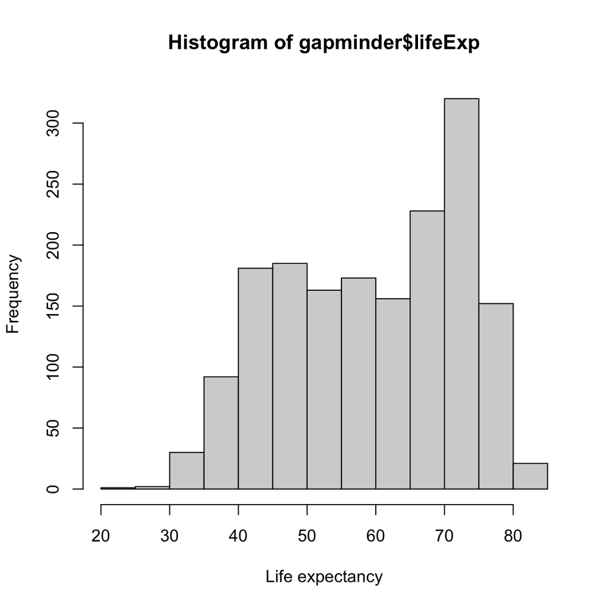

```r
hist(gapminder$lifeExp,xlab="Life expectancy")
```

Arrange figures into multiple panels with `par`

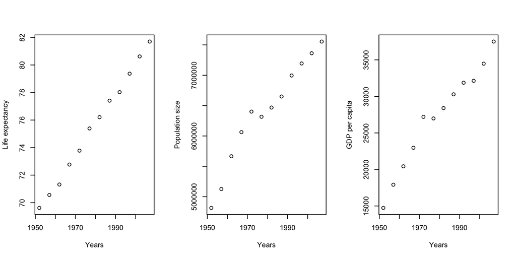

```r
df<-gapminder[gapminder$country=="Switzerland",]
par(mfrow=c(1,3))
plot(y = df$lifeExp,x=df$year,xlab="Years",ylab="Life expectancy")
plot(y = df$pop,x=df$year,xlab="Years",ylab="Population size")
plot(y = df$gdpPercap,x=df$year,xlab="Years",ylab="GDP per capita")
```

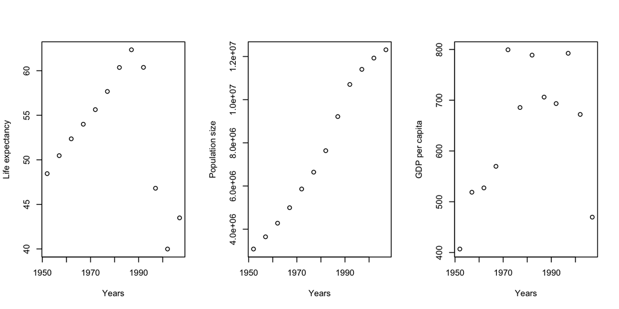

```r
df<-gapminder[gapminder$country=="Zimbabwe",]
par(mfrow=c(1,3))
plot(y = df$lifeExp,x=df$year,xlab="Years",ylab="Life expectancy")
plot(y = df$pop,x=df$year,xlab="Years",ylab="Population size")
plot(y = df$gdpPercap,x=df$year,xlab="Years",ylab="GDP per capita")
```

## 6.2 Graphics with base R and ggplot2

```r
library(ggplot2)
```

We can look at multiple countries at the same time in a prettier way

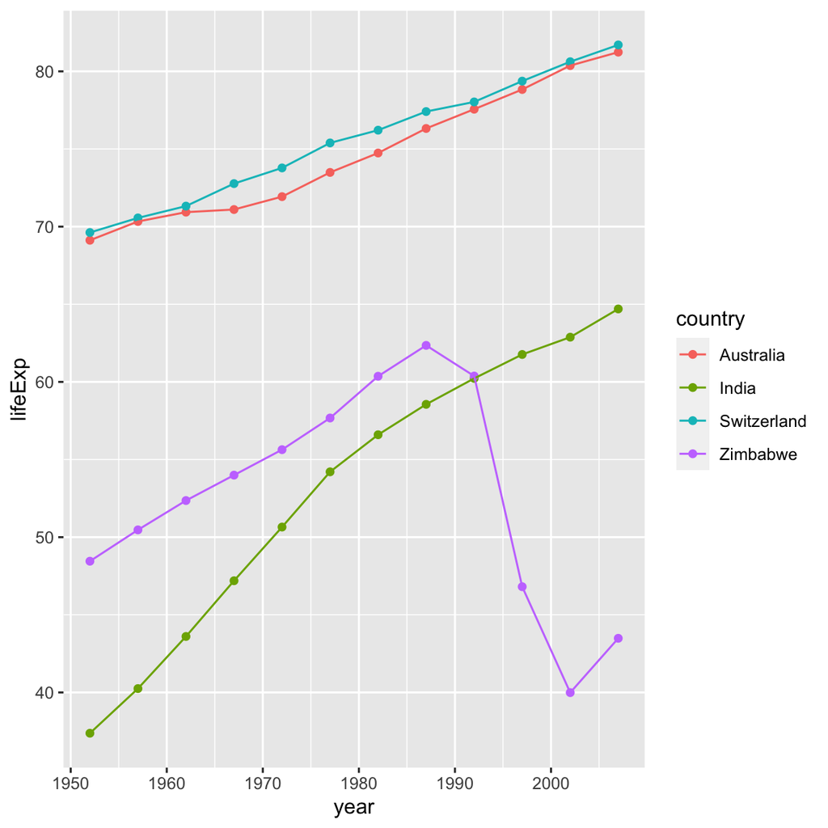

```r
df<-gapminder %>%
      mutate(country = as.character(country)) %>%
      filter(country %in% c("Switzerland","Australia","Zimbabwe","India"))

ggplot(df,aes(x=year,y=lifeExp,color=country))+
  geom_point()+
  geom_line()
```

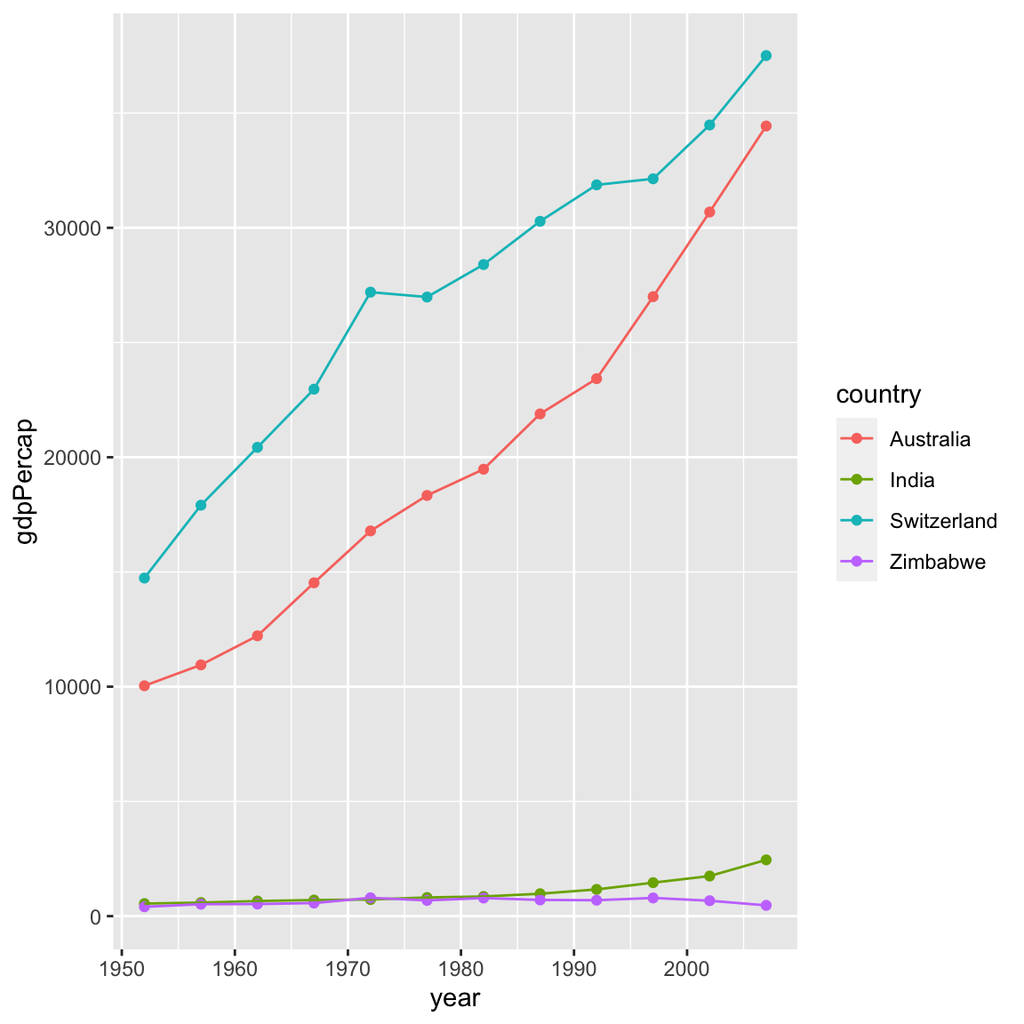

```r
ggplot(df,aes(x=year,y=gdpPercap,color=country))+
  geom_point()+
  geom_line()
```

Now, let’s plot the mean GDP per-capita over time for each continent

```r
gdp_c <- gapminder %>%
          group_by(continent,year) %>%
          summarize(mean_gdpPercap = mean(gdpPercap),
                    mean_le = mean(lifeExp),
                    min_le = min(lifeExp),
                    max_le = max(lifeExp),
                    se_le = sd(lifeExp)/sqrt(n()))
head(gdp_c)
```

```
## # A tibble: 6 × 7
## # Groups:   continent [1]
##   continent  year mean_gdpPercap mean_le min_le max_le se_le
##   <fct>     <int>          <dbl>   <dbl>  <dbl>  <dbl> <dbl>
## 1 Africa     1952          1253.    39.1   30     52.7 0.714
## 2 Africa     1957          1385.    41.3   31.6   58.1 0.779
## 3 Africa     1962          1598.    43.3   32.8   60.2 0.815
## 4 Africa     1967          2050.    45.3   34.1   61.6 0.844
## 5 Africa     1972          2340.    47.5   35.4   64.3 0.890
## 6 Africa     1977          2586.    49.6   36.8   67.1 0.944
```

```r
ggplot(gdp_c,aes(x=year,y=mean_gdpPercap,color=continent))+
  geom_point()+
  geom_line()
```

[output not shown]

We can pipe objects directly into the `ggplot()` function:

```r
gdp_c %>%
  ggplot(aes(x=year,y=mean_gdpPercap,color=continent))+
    geom_point()+
    geom_line()
```

[output not shown]

And even do this:

```r
gapminder %>%
  group_by(continent,year) %>%
  summarize(mean_gdpPercap = mean(gdpPercap)) %>%
  ggplot(aes(x=year,y=mean_gdpPercap,color=continent))+
    geom_point()+
    geom_line()
```

[output not shown]

#### 6.2.0.1 Exercise

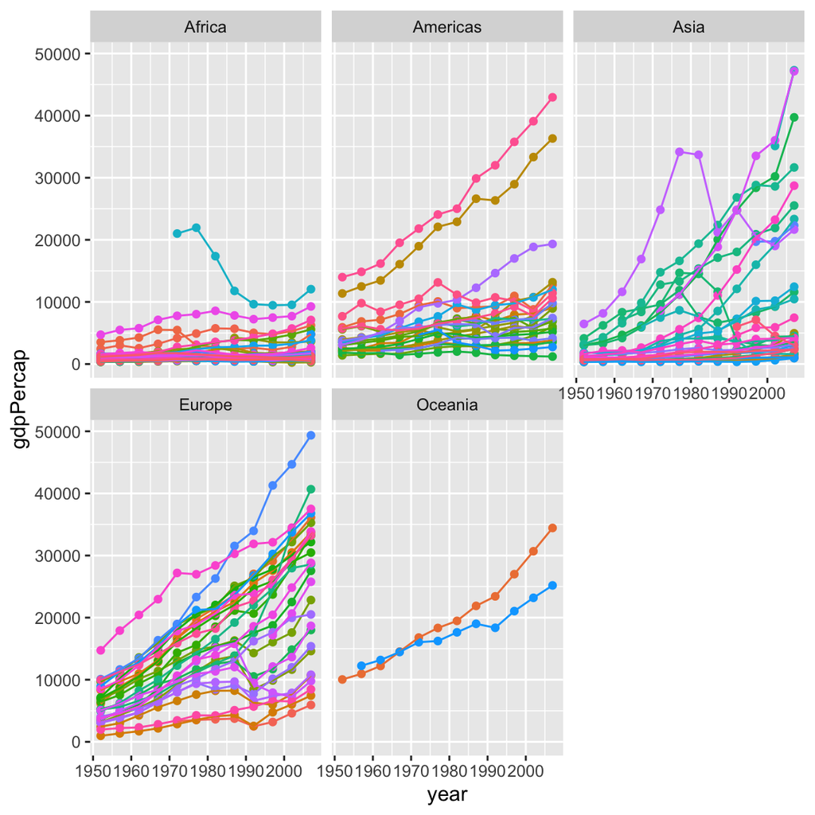

```r
gapminder %>%
  filter(pop>=2e+06) %>%
  ggplot(aes(x=year,y=gdpPercap,color=country))+
    geom_point()+
    geom_line()+
    facet_wrap(~continent)+
    theme(legend.position = "none")
```

### 6.2.1 Some ggplot tricks

Make sure your data has in the write format (wide vs long). Usually, ggplot requires the data in long format. The functions `tidyr::pivot_wider()` and `tidyr::pivot_longer()` are very useful to transform one into the other.

```r
?tidyr::pivot_wider()
?tidyr::pivot_longer()
```

To change the order of colors, modify the factor levels

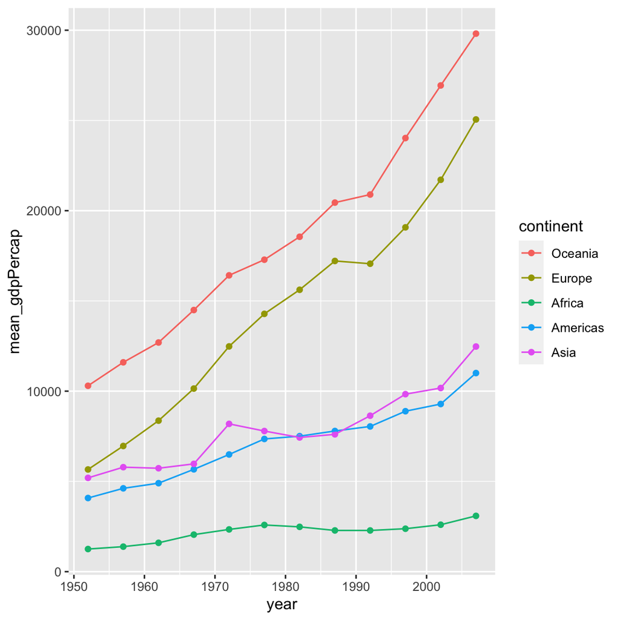

```r
gapminder %>%
  group_by(continent,year) %>%
  mutate(continent = factor(as.character(continent),levels = c("Oceania","Europe","Africa","Americas","Asia"))) %>%
  summarize(mean_gdpPercap = mean(gdpPercap)) %>%
  ggplot(aes(x=year,y=mean_gdpPercap,color=continent))+
    geom_point()+
    geom_line()
```

You can store the plots in an object and keep adding layers to it

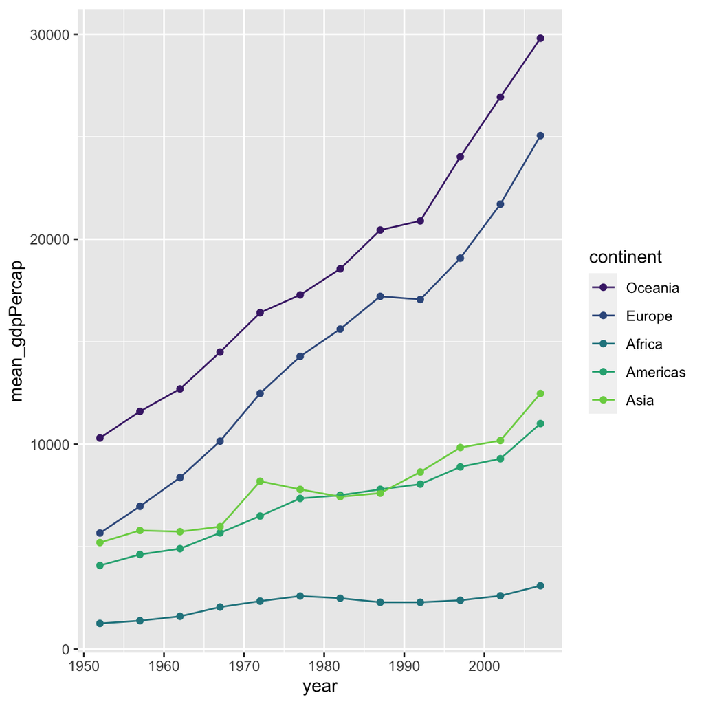

```r
p<-gapminder %>%
  group_by(continent,year) %>%
  mutate(continent = factor(as.character(continent),levels = c("Oceania","Europe","Africa","Americas","Asia"))) %>%
  summarize(mean_gdpPercap = mean(gdpPercap)) %>%
  ggplot(aes(x=year,y=mean_gdpPercap,color=continent))+
    geom_point()+
    geom_line()

# Change the color palette
p + scale_color_viridis_d(begin = 0.1,end=0.8)
```

## 6.3 Reports with RMarkdown

Live tutorial to create your first RMarkdown notebook.

# 7 Software development concepts

## 7.1 Good coding practices

### 7.1.1 Script structure

- Use comments to create sections.
- Load all required packages at the very beginning.
- Write all function definitions after package loading section or create a standalone file for your functions and call it in the main code.

### 7.1.2 Functions

Identify functions capitalizing the first letter of each word

```r
# Good
DoNothing <- function() {
  return(invisible(NULL))
}

# Bad
donothing <- function() {
  return(invisible(NULL))
}
```

Use explicit returns

```r
# Good
AddValues <- function(x, y) {
  return(x + y)
}

# Bad
AddValues <- function(x, y) {
  x + y
}
```

Define what the functions does, the input parameters, and output using comments inside the function

```r
AddValues <- function(x, y) {

  # Description: Function to add to numeric variables
  # Input
  # x = numeric
  # y = numeric
  # Output: numeric

  return(x + y)
}
```

Testing and documenting

- Use formal documentation for functions whenever you are writing more complicated projects. This documentation is written in separate `.Rd` files,and it turns into the documentation printed in the help files.
- The `roxygen2` package allows R coders to write documentation alongside the function code and then process it into the appropriate `.Rd` files.
- Formal automated tests can be written using the `testthat` package.

### 7.1.3 External packages

- Packages are essentially bundles of functions with formal documentation. Loading your own functions through `source("functions.R")` is similar to loading someone else’s using `library("package")`
- As a general rule, only load a package using `library()` if you are going to use more than two functions from if.
- Use the name space when calling an external function. Not doing it can cause clashes when two packages have a function with the same name.

```r
# Good
purrr::map()

# Bad
map()
```

## 7.2 Debugging and troubleshooting

General advice:

- Create a minimal reproducible example of your error.
- Whenever you see an error copy the full message and paste it in the search bar on your web browser. There is a lot of support out there, and most likely someone came across that same error before.

# 8 References

- [Base R Cheat Sheet](https://iqss.github.io/dss-workshops/R/Rintro/base-r-cheat-sheet.pdf)
- [Google’s R Style Guide](https://google.github.io/styleguide/Rguide.html)
- [Mastering Software Development in R](https://bookdown.org/rdpeng/RProgDA/)
- [R for reproducible statistical analysis](https://swcarpentry.github.io/r-novice-gapminder/)